# HW-W4-Problem2

Ingrid Lundeen

October 1, 2016

## Load in data

### slight change to your inital code - I’m using the read.csv function straight from the file instead since knitting is meant to be automated and not something you need to interact with so i’m sending it straight to the appropriate directory

```r
d <- read.csv("/Users/Ingrid/Desktop/zombies.csv",sep=",", header=TRUE)
```

## [1] Calculate the population mean and standard deviation for each quantitative random variable (height, weight, age, number of zombies killed, and years of education). NOTE: You will not want to use the built in var() and sd() commands as these are for samples.

```r
mean(d$height)
```

```
## [1] 67.6301
```

```r
pop_sd<-function(x) {
  sqrt(sum((x-mean(x))^2)/(length(x)))
}
pop_sd(d$height)
```

```
## [1] 4.30797
```

```r
mean(d$weight)
```

```
## [1] 143.9075
```

```r
pop_sd(d$weight)
```

```
## [1] 18.39186
```

```r
mean(d$age)
```

```
## [1] 20.04696
```

```r
pop_sd(d$age)
```

```
## [1] 2.963583
```

```r
mean(d$zombies_killed)
```

```
## [1] 2.992
```

```r
pop_sd(d$zombies_killed)
```

```
## [1] 1.747551
```

```r
mean(d$years_of_education)
```

```
## [1] 2.996
```

```r
pop_sd(d$years_of_education)
```

```
## [1] 1.675704
```

## [2] Use ggplot and make boxplots of each of these variable by gender.

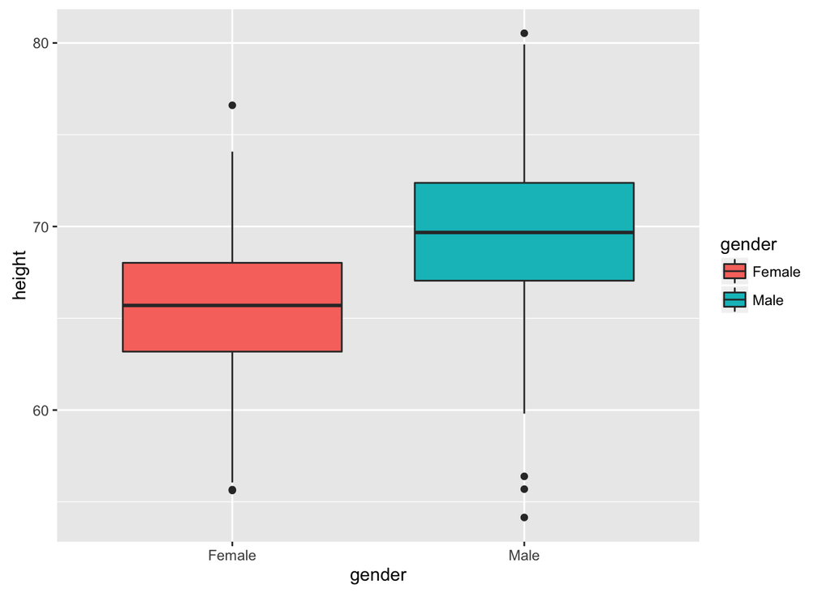

```r
library(ggplot2)
ggplot(d, aes(x=gender, y=height, fill=gender))+
  geom_boxplot()
```

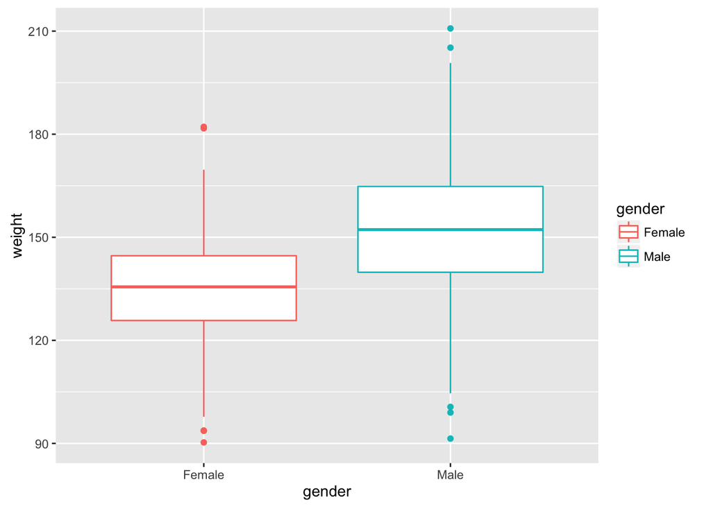

```r
ggplot(d, aes(x=gender, y=weight, color=gender))+
  geom_boxplot()
```

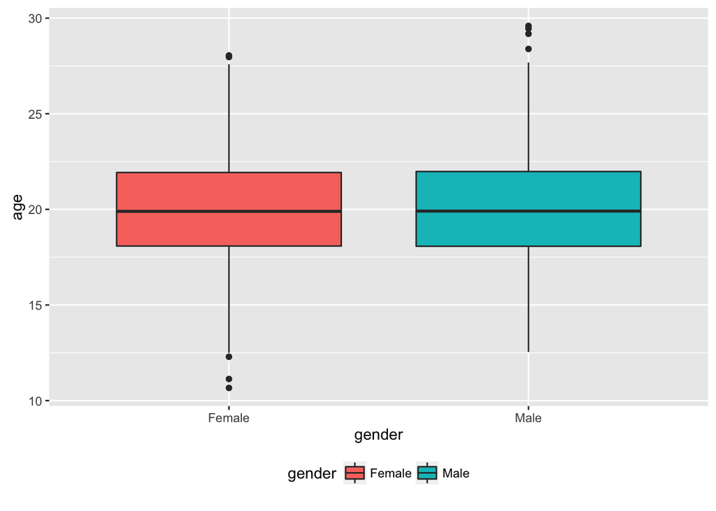

```r
ggplot(d, aes(x=gender, y=age, fill=gender))+
  geom_boxplot()+
  theme(legend.position="bottom")
```

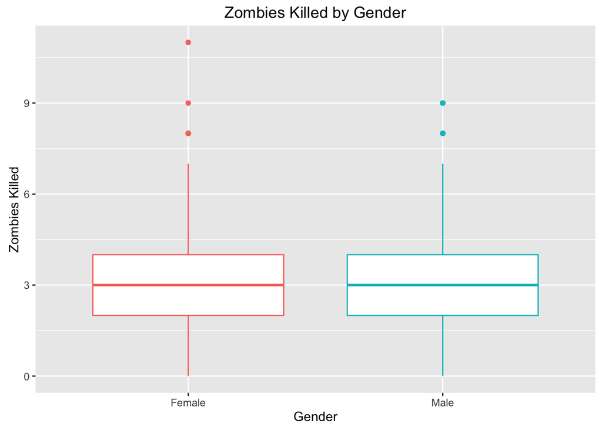

```r
ggplot(d, aes(x=gender, y=zombies_killed, color=gender))+
  geom_boxplot()+
  theme(legend.position="none")+
  labs(title="Zombies Killed by Gender", y="Zombies Killed", x="Gender")
```

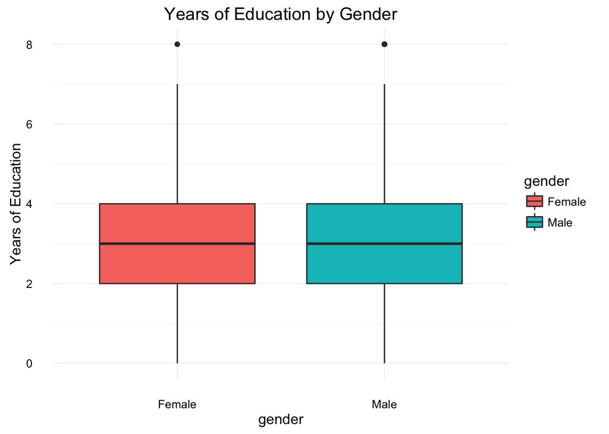

```r
ggplot(d, aes(x=gender, y=years_of_education, fill=gender))+
  geom_boxplot()+
  theme(legend.position="none")+
  theme_minimal()+
  labs(title="Years of Education by Gender", y="Years of Education")
```

### Sorry for messing around with the boxplots … it’s difficult not to with ggplot - so many options. :)

## [3] Use ggplot and make a scatterplots of height and weight in relation to age. Do these variables seem to be related? In what way?

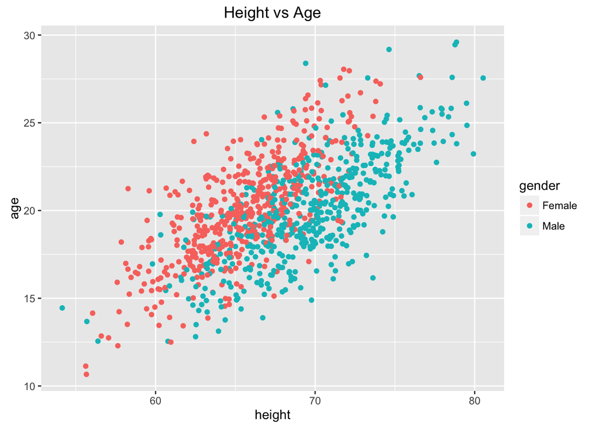

```r
ggplot(d, aes(x=height, y=age, col=gender))+
  geom_point()+
  labs(title="Height vs Age")
```

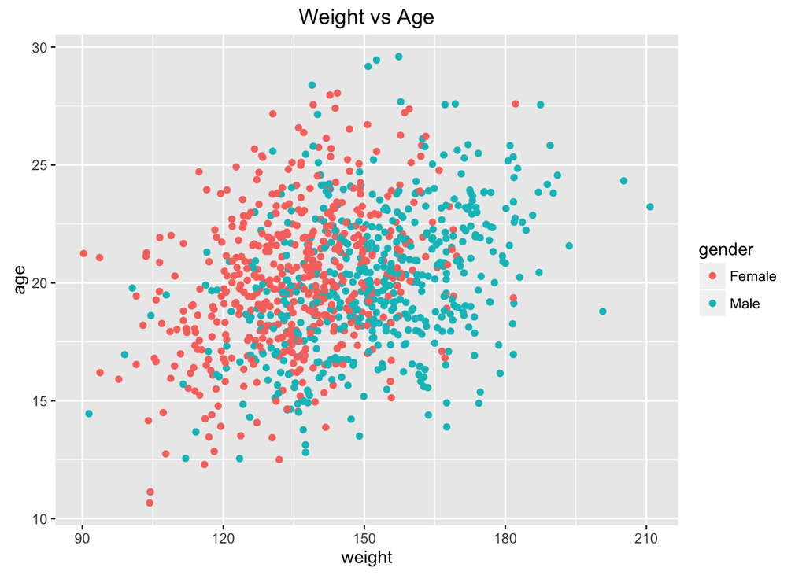

```r
ggplot(d, aes(x=weight, y=age, col=gender))+
  geom_point()+
  labs(title="Weight vs Age")
```

#### again, sorry I’m messing around with ggplot but this seems like the class to learn how to use ggplot in so I’m sure you don’t mind too much

## Both height and weight positively correlated with age. Height seems to be more correlated with age than weight - a linear relationship between the two variables.

## Lets check:

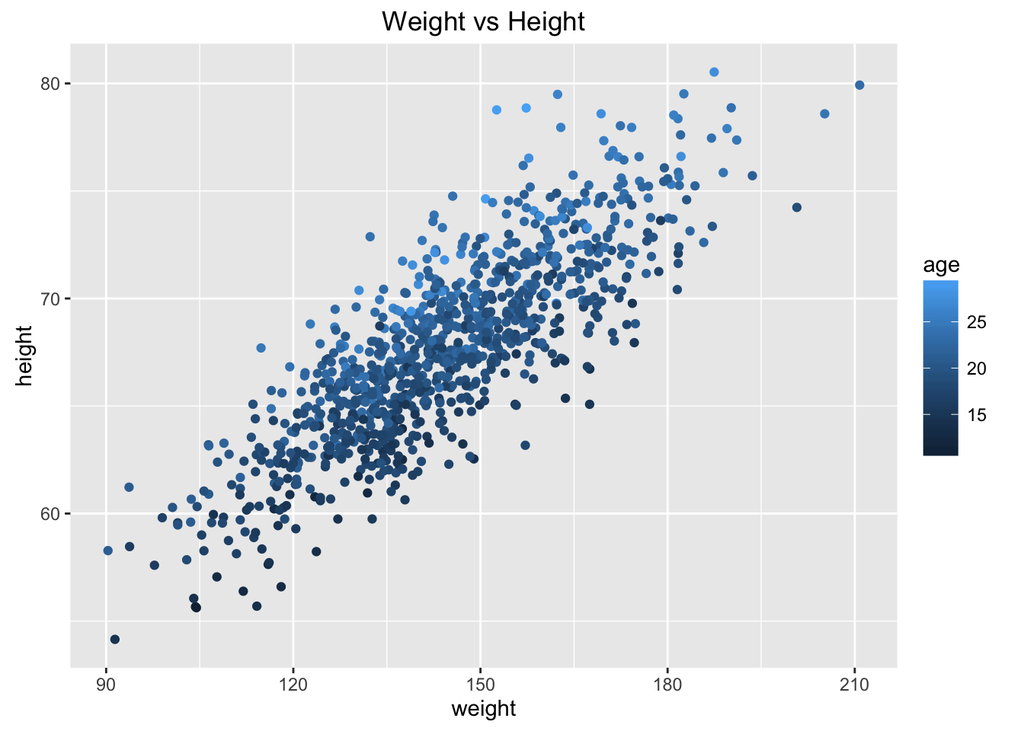

```r
ggplot(d, aes(x=weight, y=height))+
  geom_point(aes(color=age))+
  labs(title="Weight vs Height")
```

## [4] Using histograms and Q-Q plots, check whether the quantitative variables seem to be drawn from a normal distribution. Which seem to be and which do not (hint: not all are drawn from the normal distribution)? For those that are not, can you determine what common distribution they are drawn from?

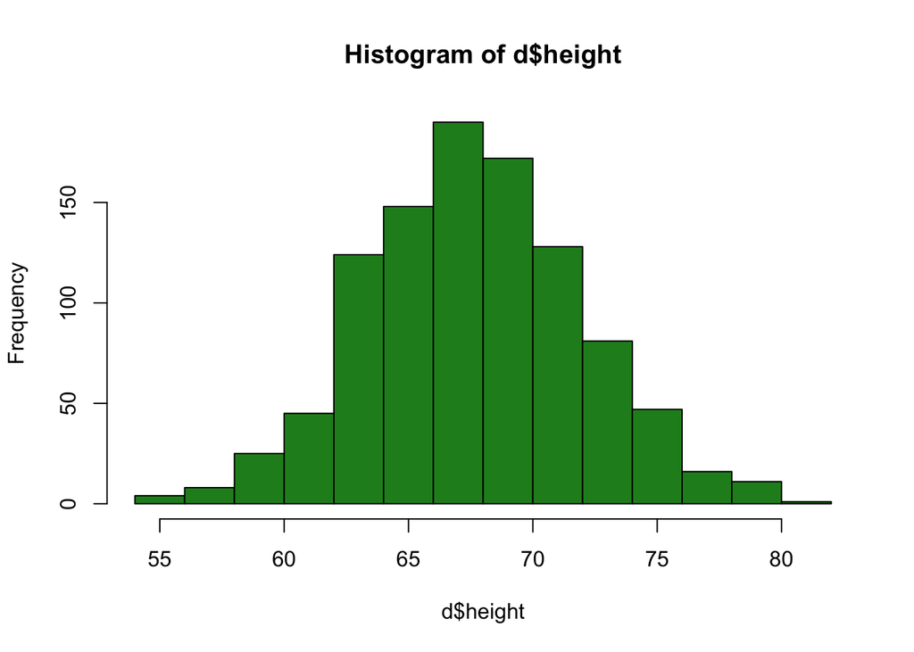

```r
hist(d$height, col="forest green")
```

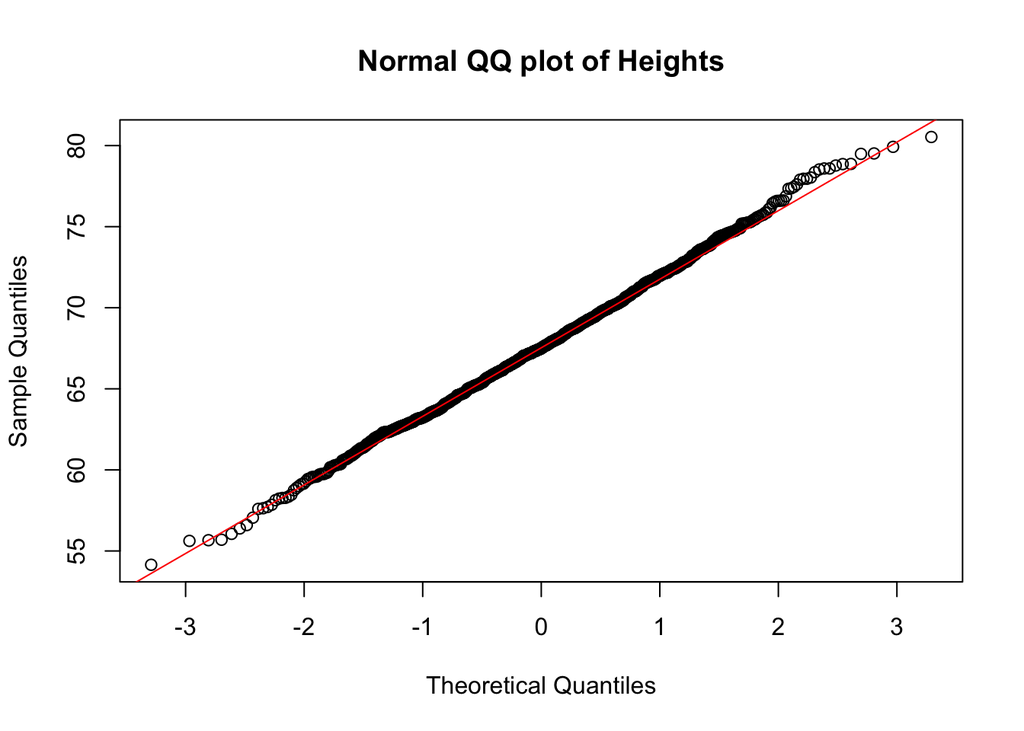

```r
qqnorm(d$height, main="Normal QQ plot of Heights")
qqline(d$height, col="red")
```

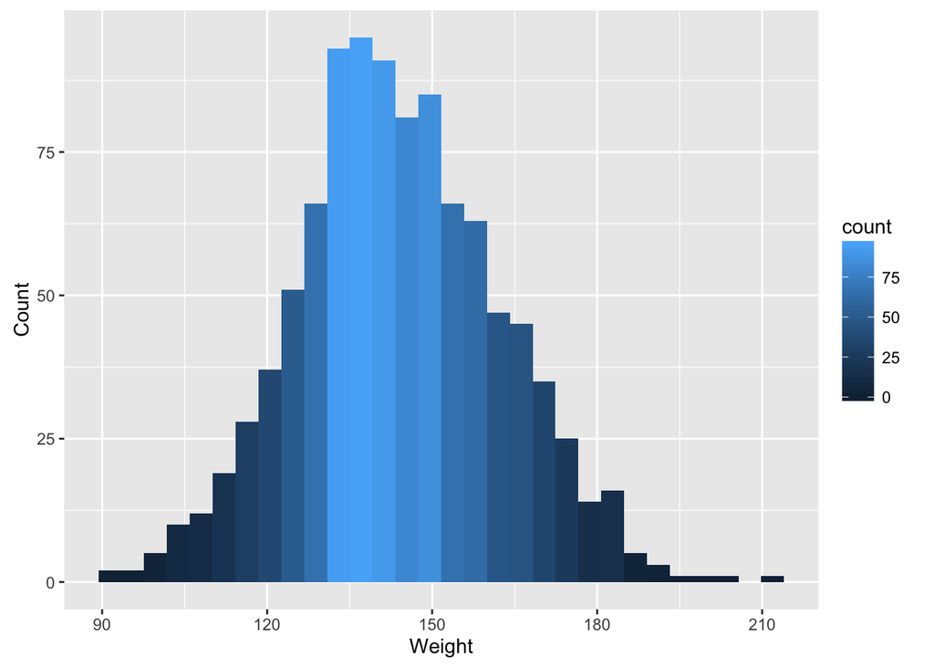

```r
ggplot(data=d, aes(d$weight)) +
  geom_histogram(aes(fill=..count..))+
  labs(x="Weight", y="Count")
```

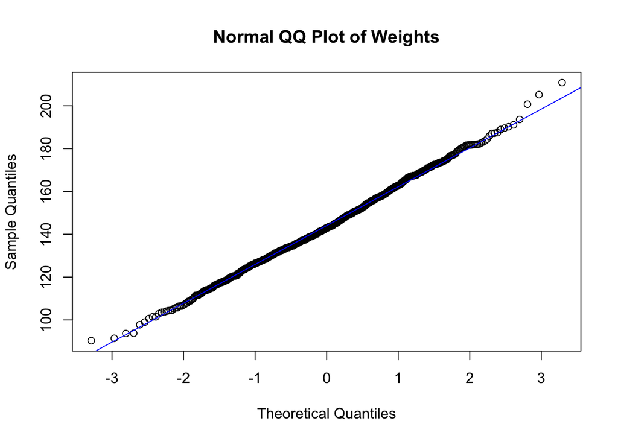

```r
qqnorm(d$weight, main="Normal QQ Plot of Weights")
qqline(d$weight, col="blue")
```

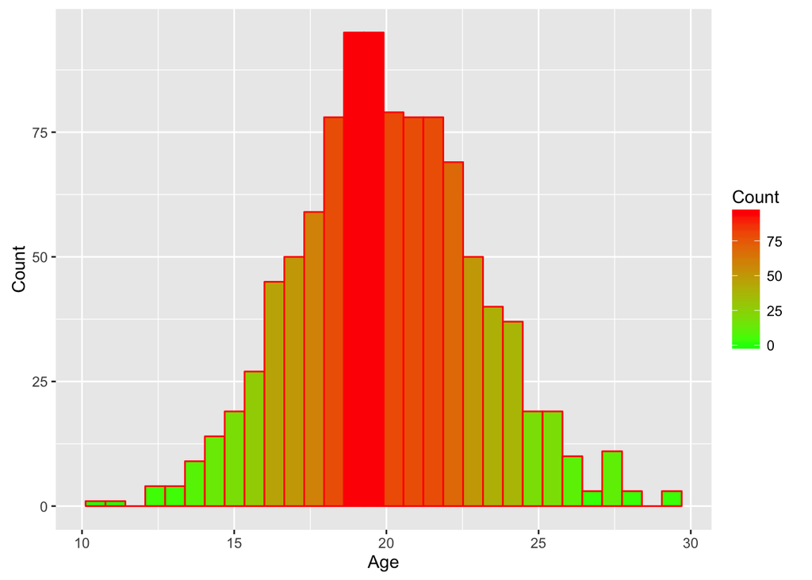

```r
ggplot(data=d, aes(d$age))+
  geom_histogram(col="red", aes(fill=..count..))+
  scale_fill_gradient("Count", low="green", high= "red")+
  labs(x="Age", y="Count")
```

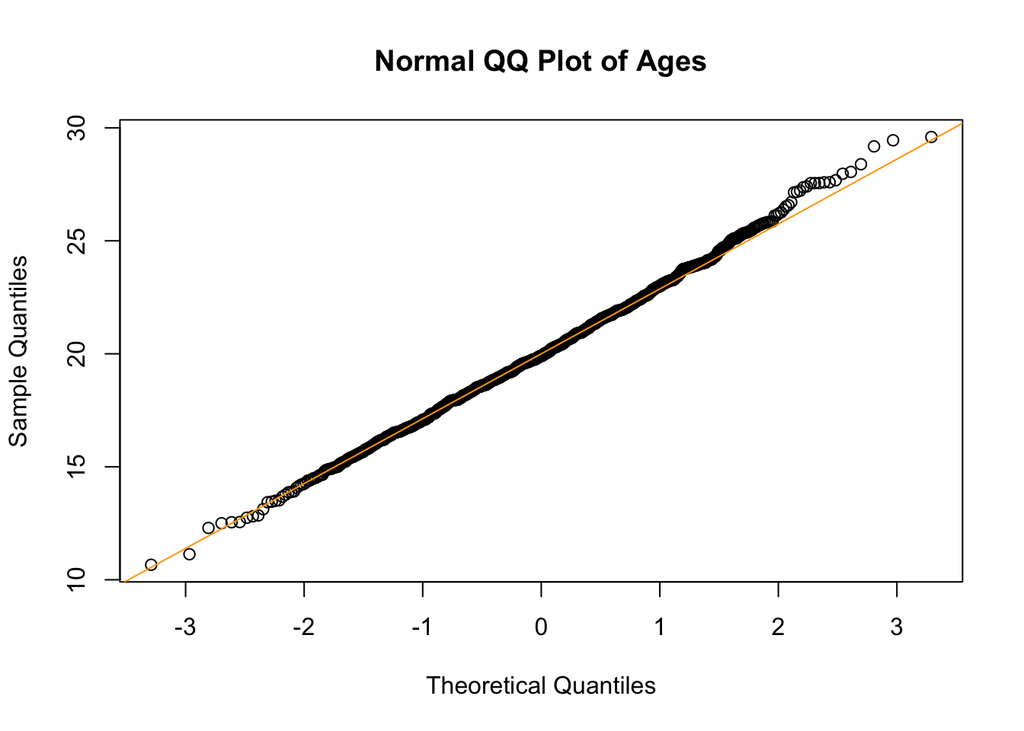

```r
qqnorm(d$age, main="Normal QQ Plot of Ages")
qqline(d$age, col="orange")
```

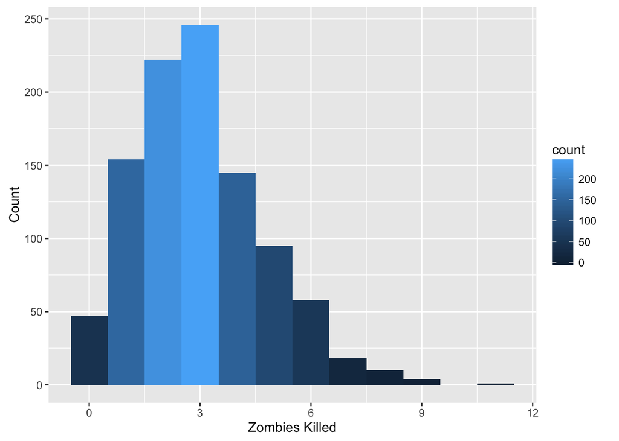

```r
qplot(zombies_killed, data=d, geom="histogram",binwidth=1, fill=..count.., xlab="Zombies Killed", ylab="Count")
```

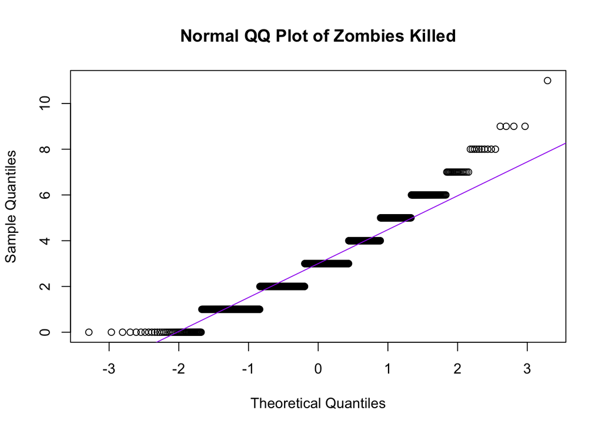

```r
qqnorm(d$zombies_killed, main="Normal QQ Plot of Zombies Killed")
qqline(d$zombies_killed, col="purple")
```

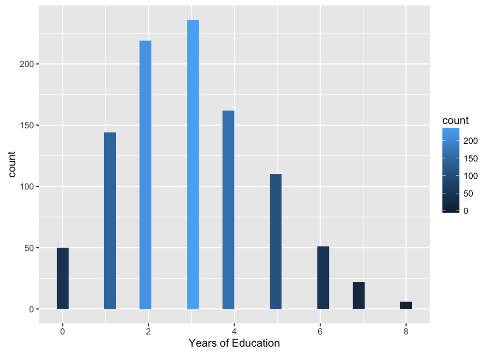

```r
ggplot(data=d, aes(d$years_of_education))+
  geom_histogram(aes(fill=..count..))+
  labs(x="Years of Education")
```

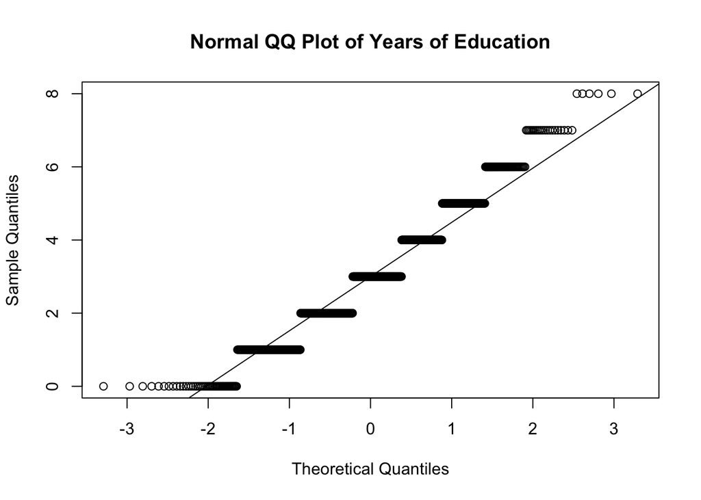

```r
qqnorm(d$years_of_education, main="Normal QQ Plot of Years of Education")
qqline(d$years_of_education, col="black")
```

###the QQ plot of Zombies killed and years of education are not normally distrubted. Poisson distributed

## [5] Now use the sample() function to sample ONE subset of 30 zombies (without replacement) from this population and calculate the mean and sample standard deviation for each variable. Also estimate the standard error for each variable and construct the 95% confidence interval for each mean. Note that for the variables that are not drawn from the normal distribution, you will need to base your estimate of the CIs on some different distribution.

```r
subset<-d[sample(1:nrow(d), 30, replace=FALSE),]

mean(subset$height)
```

```
## [1] 69.43287
```

```r
sd(subset$height)
```

```
## [1] 4.096755
```

```r
sem<-function(x){
  sd(x)/sqrt(length(x))
}
sem(subset$height)
```

```
## [1] 0.7479618
```

```r
###function for confidence intervals of normal distribution
ninetyfive<-function(x){
  c(mean(x)-2*sem(x),mean(x)+2*sem(x))
}
###prefer one below and will use it from now on.
ninetyfive.norm<-function(x){
  c(mean(x)-qnorm(1-0.05/2)*sem(x),mean(x)+qnorm(1-0.05/2)*sem(x))
}
ninetyfive.norm(subset$height)
```

```
## [1] 67.96690 70.89885
```

```r
mean(subset$weight)
```

```
## [1] 149.5855
```

```r
sd(subset$weight)
```

```
## [1] 16.96008
```

```r
sem(subset$weight)
```

```
## [1] 3.096472
```

```r
ninetyfive.norm(subset$weight)
```

```
## [1] 143.5166 155.6545
```

```r
mean(subset$age)
```

```
## [1] 20.53614
```

```r
sd(subset$age)
```

```
## [1] 2.490592
```

```r
sem(subset$age)
```

```
## [1] 0.4547179
```

```r
ninetyfive.norm(subset$age)
```

```
## [1] 19.64491 21.42737
```

```r
###writing function for confidence interval that doesnt have a normal distribution
###t-distribution
ninetyfive_off<-function(x){
  c(mean(x)-(qt(0.975,df=length(x)-1)*sem(x)), mean(x)+(qt(0.975,df=length(x)-1)*sem(x)))
}
###pois distribution
ninetyfive.pois<-function(x){
  c(mean(x)-qpois(1-0.05/2, lambda=mean(x))*sem(x), mean(x)+qpois(1-0.05/2,lambda=mean(x))*sem(x))
}
mean(subset$zombies_killed)
```

```
## [1] 2.1
```

```r
sd(subset$zombies_killed)
```

```
## [1] 1.398275
```

```r
sem(subset$zombies_killed)
```

```
## [1] 0.2552889
```

```r
ninetyfive.pois(subset$zombies_killed)
```

```
## [1] 0.8235556 3.3764444
```

```r
mean(subset$years_of_education)
```

```
## [1] 3.033333
```

```r
sd(subset$years_of_education)
```

```
## [1] 1.401559
```

```r
sem(subset$years_of_education)
```

```
## [1] 0.2558885
```

```r
ninetyfive.pois(subset$years_of_education)
```

```
## [1] 1.242114 4.824553
```

## [6] Now drawn 99 more random samples of 30 zombies out and calculate the mean for each of the these samples. Together with the first sample you drew out, you now have a set of 100 means for each variable (each based on 30 observations), which constitutes a sampling distribution for each variable. What are the means and standard deviations of this distribution for each variable? How do the standard deviations compare to the standard errors estimated in [5]? What do these sampling distributions look like? Are they normally distributed? What about for those variables that you concluded were not originally drawn from a normal distribution?

```r
k<-99
n<-30
s<-NULL
for(i in 1:k){
  s[[i]]<-d[sample(1:nrow(d), n, replace=FALSE), ]
}
m<-NULL
for(i in 1:k){
  m[i]<-mean(s[[i]]$height)
}
m
```

```
##  [1] 68.37533 66.44763 66.52096 65.85881 66.36636 67.60605 67.07317
##  [8] 66.80938 67.97723 67.79277 67.30902 68.30085 67.41074 67.41496
## [15] 67.09874 68.75551 67.81816 67.73866 69.03030 66.61474 67.19377
## [22] 66.72941 68.17998 68.30445 68.87606 67.40923 68.40953 68.10193
## [29] 66.93386 68.12617 66.58102 66.08588 67.59164 67.54468 68.39640
## [36] 66.67060 68.80854 67.68649 68.02949 68.73571 67.88453 66.92132
## [43] 65.87601 67.42668 66.99385 67.07873 68.04693 67.34473 67.54497
## [50] 66.23900 67.07708 65.44822 67.93655 68.61491 68.73941 67.55003
## [57] 66.92677 67.58394 68.12544 67.36008 67.22787 67.22758 67.44012
## [64] 66.91576 68.80865 67.36388 67.98775 66.08061 66.92534 68.58914
## [71] 68.08910 68.04579 66.26486 67.75006 67.81624 68.38553 67.83061
## [78] 67.65173 65.96370 67.80635 66.94589 67.90302 67.74325 66.98971
## [85] 67.44672 67.29988 66.46645 67.89182 67.50899 66.41583 66.93722
## [92] 66.99888 66.61199 66.37869 66.89079 67.47733 67.52107 66.91568
## [99] 67.25915
```

```r
h_mean<-c(m,mean(subset$height))
h_mean
```

```
##   [1] 68.37533 66.44763 66.52096 65.85881 66.36636 67.60605 67.07317
##   [8] 66.80938 67.97723 67.79277 67.30902 68.30085 67.41074 67.41496
##  [15] 67.09874 68.75551 67.81816 67.73866 69.03030 66.61474 67.19377
##  [22] 66.72941 68.17998 68.30445 68.87606 67.40923 68.40953 68.10193
##  [29] 66.93386 68.12617 66.58102 66.08588 67.59164 67.54468 68.39640
##  [36] 66.67060 68.80854 67.68649 68.02949 68.73571 67.88453 66.92132
##  [43] 65.87601 67.42668 66.99385 67.07873 68.04693 67.34473 67.54497
##  [50] 66.23900 67.07708 65.44822 67.93655 68.61491 68.73941 67.55003
##  [57] 66.92677 67.58394 68.12544 67.36008 67.22787 67.22758 67.44012
##  [64] 66.91576 68.80865 67.36388 67.98775 66.08061 66.92534 68.58914
##  [71] 68.08910 68.04579 66.26486 67.75006 67.81624 68.38553 67.83061
##  [78] 67.65173 65.96370 67.80635 66.94589 67.90302 67.74325 66.98971
##  [85] 67.44672 67.29988 66.46645 67.89182 67.50899 66.41583 66.93722
##  [92] 66.99888 66.61199 66.37869 66.89079 67.47733 67.52107 66.91568
##  [99] 67.25915 69.43287
```

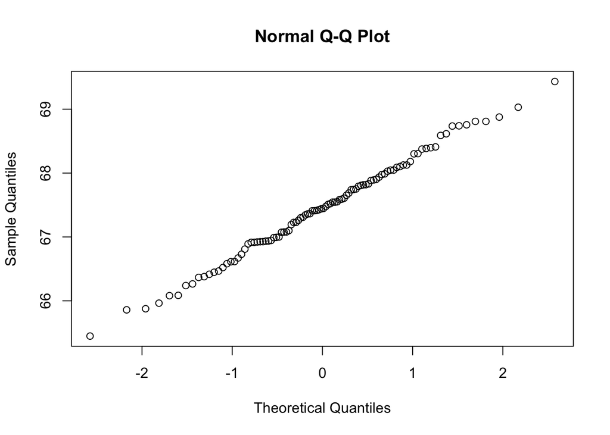

```r
msd<-NULL
for(i in 1:k){
  msd[i]<-sd(s[[i]]$height)
}
h_msd<-c(msd,sd(subset$height))
qqnorm(h_mean)
```

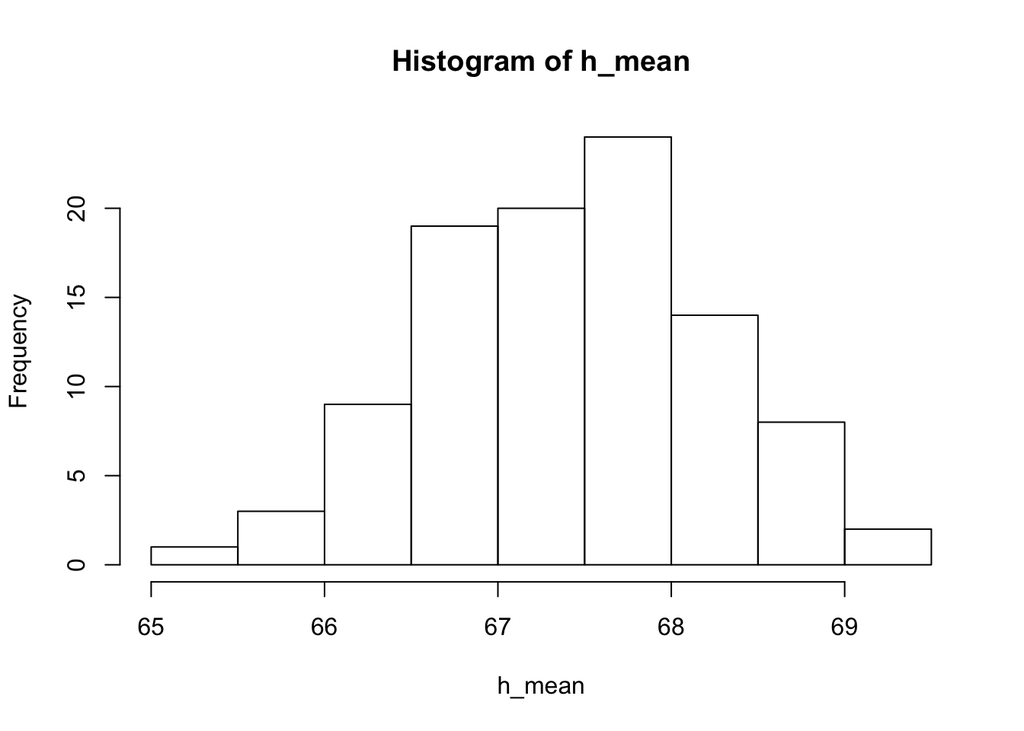

```r
hist(h_mean)
```

```r
mean(h_mean)
```

```
## [1] 67.44639
```

```r
sd(h_msd)
```

```
## [1] 0.4675588
```

### the standard deviation is less than the previously calculated standard error

### based on the qq plot and histogram, the distribution of this looks fairly normal

```r
l<-NULL
for(i in 1:k){
  l[i]<-mean(s[[i]]$weight)
}
w_mean<-c(l,mean(subset$weight))
w_mean
```

```
##   [1] 146.7784 140.0350 141.6657 135.5493 142.5579 142.0871 140.6268
##   [8] 141.9640 147.4620 144.7212 141.0383 147.0516 142.6312 140.9506
##  [15] 139.3316 147.2783 145.6384 146.0064 149.9795 138.2416 141.6806
##  [22] 143.8516 148.3501 145.4428 148.2971 144.2685 147.7012 145.7386
##  [29] 137.8925 146.2284 138.3252 135.3972 143.9818 142.6724 146.9599
##  [36] 138.6266 147.0860 139.5259 148.7663 149.1898 144.6268 138.4382
##  [43] 139.6633 141.2754 144.3621 146.2012 144.8673 141.6852 144.0586
##  [50] 140.7672 140.5595 134.0375 145.8657 147.2735 146.4605 146.2104
##  [57] 139.5060 146.5567 144.8032 141.8942 141.0164 142.1426 140.9141
##  [64] 142.7014 149.1815 141.6925 145.1471 137.8360 139.5147 145.9564
##  [71] 142.5734 146.7355 137.0674 145.2917 144.3322 145.2611 142.5333
##  [78] 144.6220 135.0436 142.1316 142.3066 146.3781 142.2409 137.5955
##  [85] 139.6951 141.5491 139.8005 140.8994 143.5400 141.6199 144.1351
##  [92] 136.7254 140.7784 141.0235 139.8705 141.3684 143.1085 141.9279
##  [99] 140.8235 149.5855
```

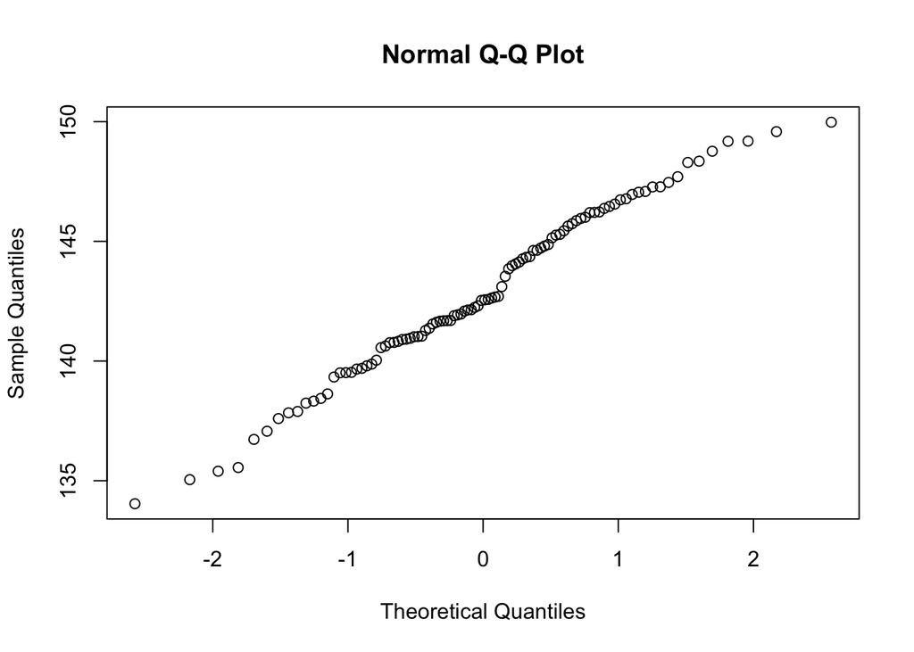

```r
wsd<-NULL
for(i in 1:k){
  wsd[i]<-sd(s[[i]]$weight)
}
w_wsd<-c(wsd,sd(subset$weight))
qqnorm(w_mean)
```

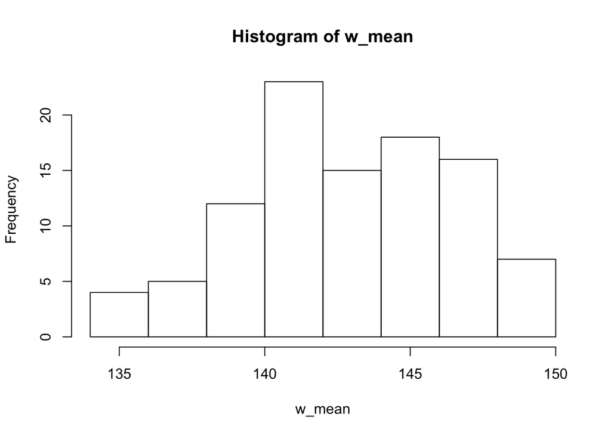

```r
hist(w_mean)
```

```r
mean(w_mean)
```

```
## [1] 142.8736
```

```r
sd(w_wsd)
```

```
## [1] 2.329836
```

### sd calculated here is smaller than the earlier calculated standard error

### based on qqplot and histogram, the distribution looks normal

```r
a<-NULL
for (i in 1:k){
  a[i]<-mean(s[[i]]$age)
}
a_mean<-c(a,mean(subset$age))
a_mean
```

```
##   [1] 20.40990 19.07600 19.38383 19.90941 18.83118 19.81363 19.86358
##   [8] 19.30861 19.65563 19.87785 20.22666 20.19255 19.95759 20.20138
##  [15] 20.41698 21.17195 19.79294 19.89690 20.50591 19.97674 20.15987
##  [22] 19.37294 20.08716 20.61002 20.20948 19.85178 20.15559 20.20120
##  [29] 19.62646 20.54874 19.13518 19.50010 20.22917 20.59334 20.97950
##  [36] 19.49275 21.02672 20.11806 19.71836 20.35159 20.32572 19.82514
##  [43] 18.76589 20.37968 19.51759 19.37848 20.20718 20.38080 20.01551
##  [50] 19.04854 19.96376 19.16486 19.84270 20.26085 20.94691 19.26504
##  [57] 19.87149 19.88641 20.63680 20.16991 20.34698 19.39694 19.87352
##  [64] 19.48600 21.12052 20.12571 20.63841 19.10957 20.31215 20.02675
##  [71] 20.83494 20.04475 19.79447 20.55692 19.84370 20.75574 20.51994
##  [78] 19.75925 19.58199 20.21210 20.02634 20.03787 20.98718 20.17279
##  [85] 20.51961 19.01583 19.15884 20.63221 19.35536 18.31310 19.40905
##  [92] 20.02617 19.66211 18.76748 19.67311 20.47714 19.70390 19.70206
##  [99] 20.37731 20.53614
```

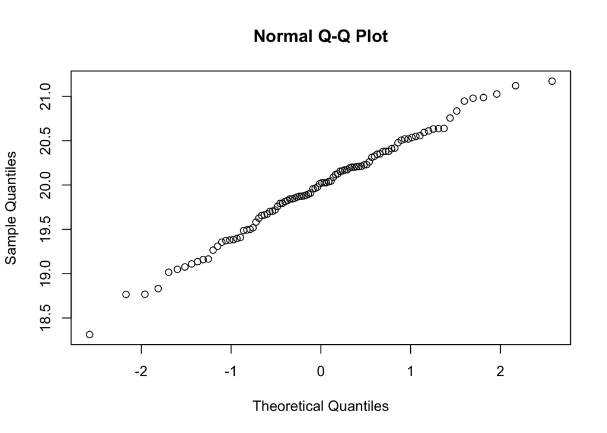

```r
asd<-NULL
for(i in 1:k){
  asd[i]<-sd(s[[i]]$age)
}
a_asd<-c(asd,sd(subset$age))
qqnorm(a_mean)
```

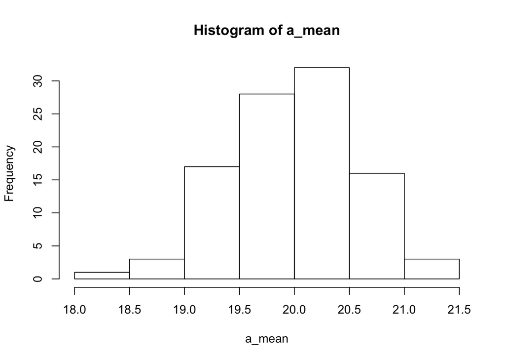

```r
hist(a_mean)
```

```r
mean(a_mean)
```

```
## [1] 19.97184
```

```r
sd(a_asd)
```

```
## [1] 0.3761687
```

### sd calculated here is smaller than previously calculated standard error

### based on qq plot and histogram - appears fairly normally distributed

```r
z<-NULL
for (i in 1:k){
  z[i]<-mean(s[[i]]$zombies_killed)
}
z_mean<-c(z,mean(subset$zombies_killed))
z_mean
```

```
##   [1] 3.500000 3.033333 2.633333 2.866667 3.133333 3.233333 3.266667
##   [8] 3.066667 2.766667 2.866667 2.900000 2.300000 3.000000 2.966667
##  [15] 2.966667 2.733333 3.333333 2.866667 3.300000 3.133333 3.566667
##  [22] 2.933333 2.600000 3.100000 2.666667 3.233333 3.166667 2.666667
##  [29] 3.033333 3.033333 2.900000 2.333333 3.233333 2.866667 3.333333
##  [36] 2.933333 3.466667 3.066667 3.033333 3.066667 3.100000 3.233333
##  [43] 3.200000 3.066667 3.300000 3.533333 3.266667 3.366667 2.500000
##  [50] 2.500000 2.900000 2.366667 3.600000 2.300000 2.600000 2.700000
##  [57] 2.833333 2.733333 3.800000 3.166667 3.200000 3.533333 3.133333
##  [64] 2.866667 2.800000 2.633333 3.033333 3.333333 3.433333 2.533333
##  [71] 2.966667 3.100000 3.066667 3.333333 2.866667 2.200000 2.633333
##  [78] 2.900000 3.766667 3.066667 3.266667 3.100000 2.700000 3.233333
##  [85] 2.700000 2.866667 2.933333 2.966667 2.800000 2.933333 2.866667
##  [92] 2.933333 2.900000 2.766667 2.533333 2.566667 3.166667 3.000000
##  [99] 2.500000 2.100000
```

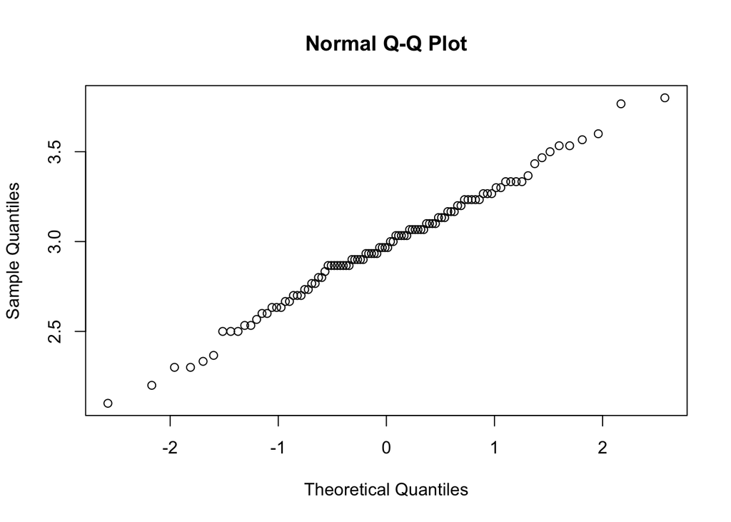

```r
zsd<-NULL
for(i in 1:k){
  zsd[i]<-sd(s[[i]]$zombies_killed)
}
z_sd<-c(zsd,sd(subset$zombies_killed))
qqnorm(z_mean)
```

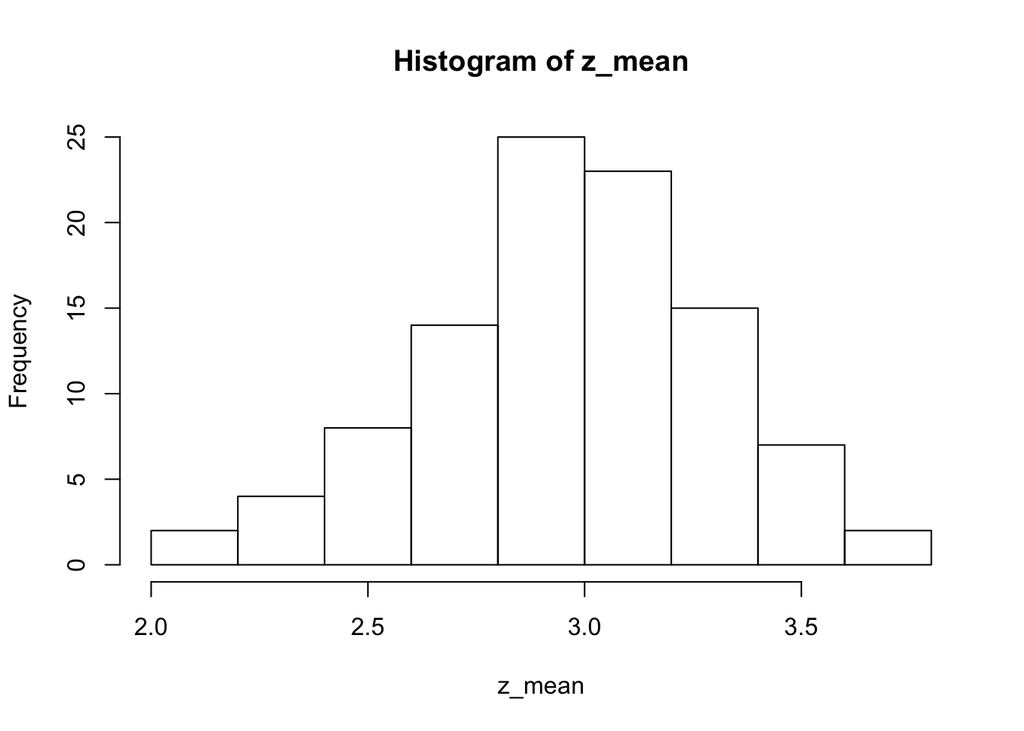

```r
hist(z_mean)
```

```r
mean(z_mean)
```

```
## [1] 2.974
```

```r
sd(zsd)
```

```
## [1] 0.262577
```

### basd on qqplot and histogram, looks normally distributed - this was not the case in the previous example - with repeated sampling becomes more normally distributed

```r
y<-NULL
for (i in 1:k){
  y[i]<-mean(s[[i]]$years_of_education)
}
y_mean<-c(y,mean(subset$years_of_education))
y_mean
```

```
##   [1] 2.833333 3.700000 2.733333 2.733333 2.900000 2.966667 2.666667
##   [8] 2.566667 3.533333 2.933333 3.400000 3.666667 2.800000 3.233333
##  [15] 2.966667 2.833333 2.566667 3.033333 3.166667 3.000000 3.166667
##  [22] 3.333333 3.066667 2.933333 3.000000 3.166667 2.866667 3.266667
##  [29] 3.466667 2.866667 2.500000 3.133333 3.300000 2.966667 3.233333
##  [36] 2.700000 3.400000 3.133333 2.933333 2.333333 3.033333 3.100000
##  [43] 2.900000 2.966667 3.000000 3.000000 3.000000 3.166667 3.066667
##  [50] 3.300000 3.066667 2.933333 3.266667 2.933333 2.966667 3.500000
##  [57] 2.866667 2.933333 3.100000 3.566667 3.033333 3.133333 3.333333
##  [64] 3.266667 3.166667 3.300000 3.200000 2.733333 2.766667 3.066667
##  [71] 3.233333 3.066667 3.333333 3.133333 3.200000 2.933333 2.966667
##  [78] 3.000000 2.700000 2.733333 3.533333 3.300000 3.000000 3.166667
##  [85] 2.733333 2.833333 2.633333 2.800000 2.933333 2.966667 3.000000
##  [92] 2.833333 2.566667 2.833333 2.733333 3.066667 2.700000 2.466667
##  [99] 2.833333 3.033333
```

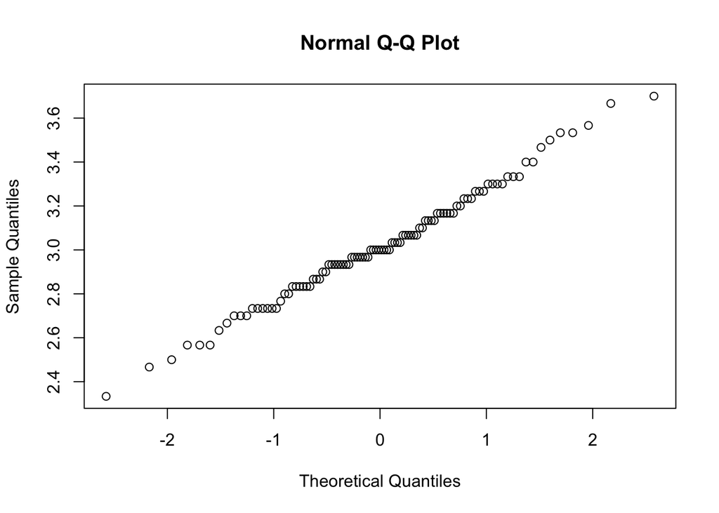

```r
ysd<-NULL
for(i in 1:k){
  ysd[i]<-sd(s[[i]]$years_of_education)
}
y_sd<-c(ysd,sd(subset$years_of_education))
qqnorm(y_mean)
```

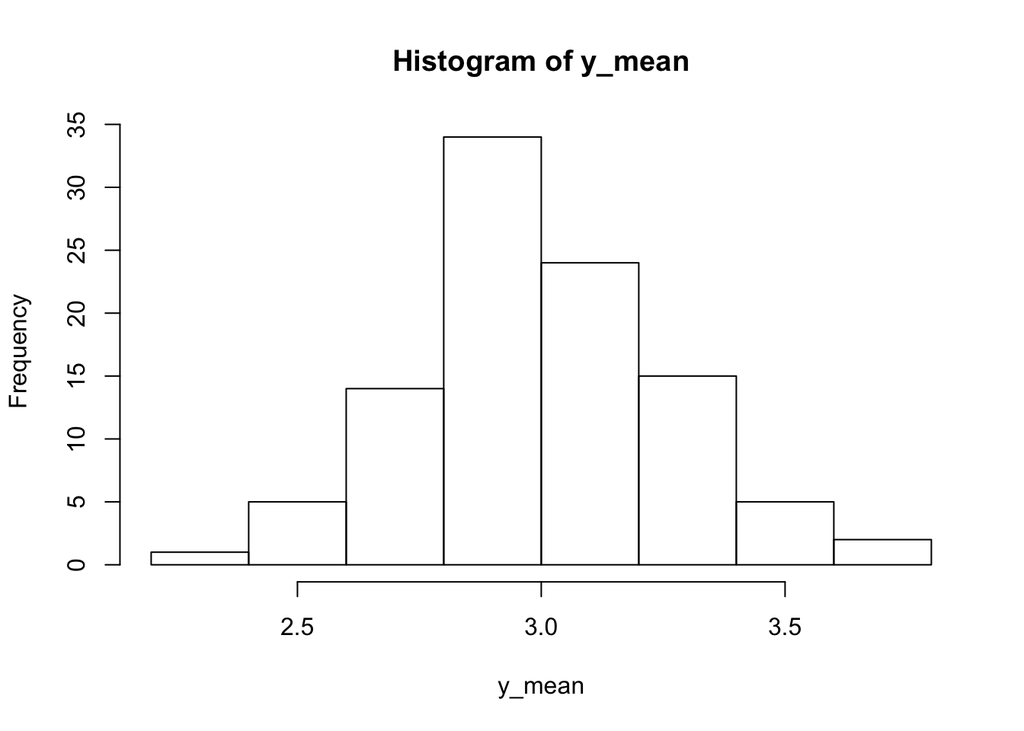

```r
hist(y_mean)
```

```r
mean(y_mean)
```

```
## [1] 3.019333
```

```r
sd(y_sd)
```

```
## [1] 0.21406
```

### standard deviation is smaller than calculated standard error from [5]

### based on qqplot and histogram this looks like a normal distribution - unlike what it was before - with an increase in sampling comes increased normality of the distribution